# ANOVA y Tukey HSD

# INTRODUCCION

A un nivel mayor de complejidad que las pruebas de T el ANOVA (Analysis of variance) es una formula estadistica que se utiliza para comparar varianzas entre las medias de diferencia (*mas de dos*) grupos.

Existe el ANOVA de una via en la que solo se tiene una variable independiente ( con varios grupos) y se quiere ver la diferencia entre dichos grupos sobre una variable dependiente.

El ANOVA de 2 vias añade otra variable independiente por lo que mide el efecto de dos variables independientes sobre una variable dependiente. Tambien existe la ANOVA de tres vias pero la complejidad en comparaciones y tratamientos crece bastate.

```r
library(car)
```

# ANOVA de una via

Es decir solo UN tratamiento independiente

# ANOVA con R base

R base puede calcular ANOVA de dos maneras diferentes, una de ellas usando el codigo *anova()*. Sin embargo, esta funcion base calcula automaticamente una ANOVA tipo I la cual da por sentado que los datos son balanceados por lo que cuando no sea asi se debe de usar la funcion del paquete *car*

```r
anova(lm(shift~treatment, data = Rodillas))
```

```
Analysis of Variance Table

Response: shift
          Df Sum Sq Mean Sq F value   Pr(>F)
treatment  2 7.2245  3.6122  7.2894 0.004472 **
Residuals 19 9.4153  0.4955
---
Signif. codes:  0 ‘***’ 0.001 ‘**’ 0.01 ‘*’ 0.05 ‘.’ 0.1 ‘ ’ 1
```

sin embargo, para fines utiles siempre usar el aov() ya que por definicion significa analisis de varianza

# ANOVA con el paquete CAR

```r
Anova(rod_anova) # fijarse que va con mayuscula
```

```
Anova Table (Type II tests)

Response: shift
          Sum Sq Df F value   Pr(>F)
treatment 7.2245  2  7.2894 0.004472 **
Residuals 9.4153 19
---
Signif. codes:  0 ‘***’ 0.001 ‘**’ 0.01 ‘*’ 0.05 ‘.’ 0.1 ‘ ’ 1
```

La diferencia principal entre el tipo II y tipo III es la interaccion de los grupos de las variables independientes. Por ejemplo es recomendable usar tipo II si no estan seguros si sus variables interactucan entre si osea que esten desbalanceados

*CONCLUSION* si p<0.05 es diferente osea hay diferencias

# Tukey HSD

En el caso que una ANOVA nos muestre que existen diferencias significativas entre tratamientos, el paso siguiente es correr un test de Tukey HSD en el cual nos “desglosa” la ANOVA y nos dice cuales de los tratamientos son diferentes.

Para esto solo hay un codigo el cual es *TukeyHSD()*

IMPORTANTE; el ANOVA te dice que si hay diferencias y el TUKEY te dice cuales son las diferencias.

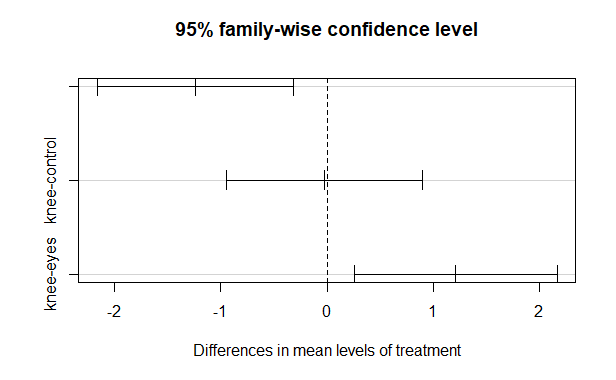

## Ejercicio

Usando el dataframe de *Estanques* vamos a comparar la calidad del agua en los estanques entre tres regiones diferentes de Alaska. Para ello cada uno de ustedes seleccionar una de las variables y llevar a cabo un test ANOVA. No olviden tomar en cuenta los pasos:

- checar normalidad y de no estar estandarizado transformar
- checar si el set de datos esta balanceado (para elegir el tipo de ANOVA) *checar homogeneidad de varianza* Calcular ANOVA y si es significativa calcular Tukey HSD *Hacer un grafica del resultado Tukey

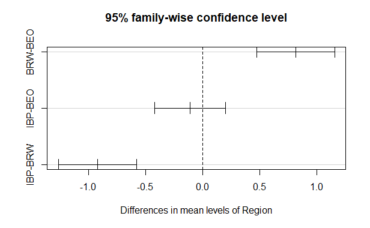

# IMPORTANTE SABER QUE

Cuando hay datos con 0 los tomaria el programa como datos infinitos y al programa no le sirven esos datos por lo cual hay que ponerle un +1 a la columna que tiene esos datos y asi correra.

# ANOVA DE 2 VIAS

Aunque este tipo de analisis es sumamente util, muchas veces nuestros experimentos incluyen mas de una variable independiente que manipulamos. Para ello los datos se pueden comparar usando una ANOVA es de 2 o mas vias.

```r
#Balanceado?
Comp_suelos %>%
  group_by(Temperature,Soil) %>%
  summarise(n())
```

| Temperature | Soil | n() |
| --- | --- | --- |
| 17 deg | active layer | 6 |
| 17 deg | permafrost | 6 |
| 7 deg | active layer | 6 |
| 7 deg | permafrost | 6 |

#### EJERCICIO

Ahora les toca a ustedes cada quien va a elegir 1 variable y comparar los efectos de temperatura y tipo de suelo en ellas. Tienen que seguir el mismo proceso y al final me van a explicar porque si o no hay diferencia significatica entre los grupos.

```r
summary(TDP_anova)
```

```
                 Df Sum Sq Mean Sq F value   Pr(>F)
Temperature       1 0.6572  0.6572 105.968 1.94e-09 ***
Soil              1 0.0007  0.0007   0.115 0.737687
Temperature:Soil  1 0.1011  0.1011  16.296 0.000646 ***
Residuals        20 0.1240  0.0062
---
Signif. codes:  0 ‘***’ 0.001 ‘**’ 0.01 ‘*’ 0.05 ‘.’ 0.1 ‘ ’ 1
```